# Regression Models

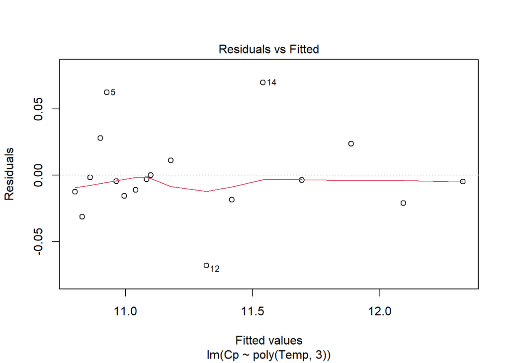

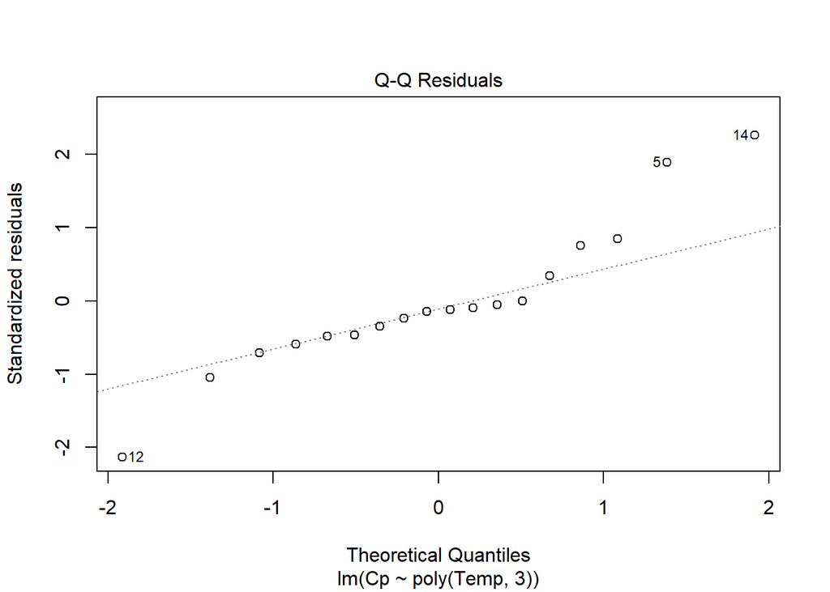

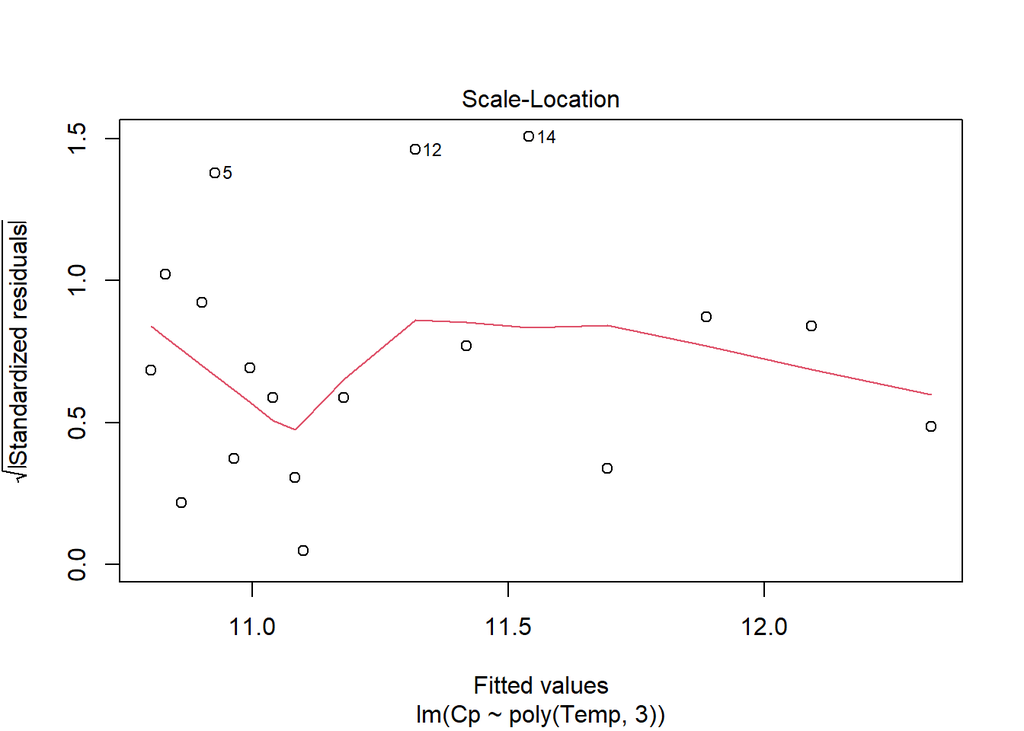

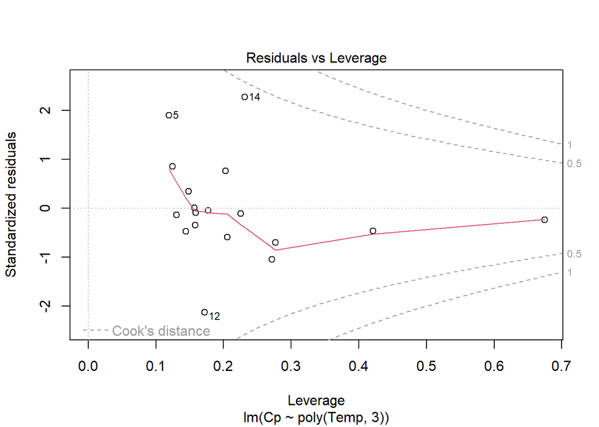

```
## [[1]]
## [1]    4.0000 -119.2705
##
## [[2]]
## [1]    7.0000 -117.1797
##
## [[3]]
## [1]   10.0000 -128.3144
```

Of these three models, lm.ns has the smallest AIC.

### fixing identified outliers

after applying remedies to ensure linearity and constant variance, observations identified as outliers or influential may no longer present. Sometimes, however, they do remain.

- first step: identify thier cause
  - by mistake: mis-recorded observations, then correct or discard the observation.
  - from a different population: dsicarded.
  - no known reason for why it may be an outlier: An outlier that is not a mistake suggests that a different or more complex model may be necessary. One strategy to evaluate the influence of the outlier is to fit the model to the data with and without the outlier. If the two models are materially different, perhaps other types of models should be considered.

### collinearity

Collinearity means that different combinations of the covariates may lead to nearly the same fitted values. Collinearity is therefore mainly a problem for interpretation rather than prediction.

A special case of collinearity occurs when a covariate and a power of the covariate are included in the same model. Using orthogonal polynomials or regression splines avoids this problem.

If collinearity is detected or suspected, remedies include:

- Omitting some explanatory variables
- Combine explanatory variables in the model provided the combination makes sense.
- Use special methods, such as ridge, lasso regression

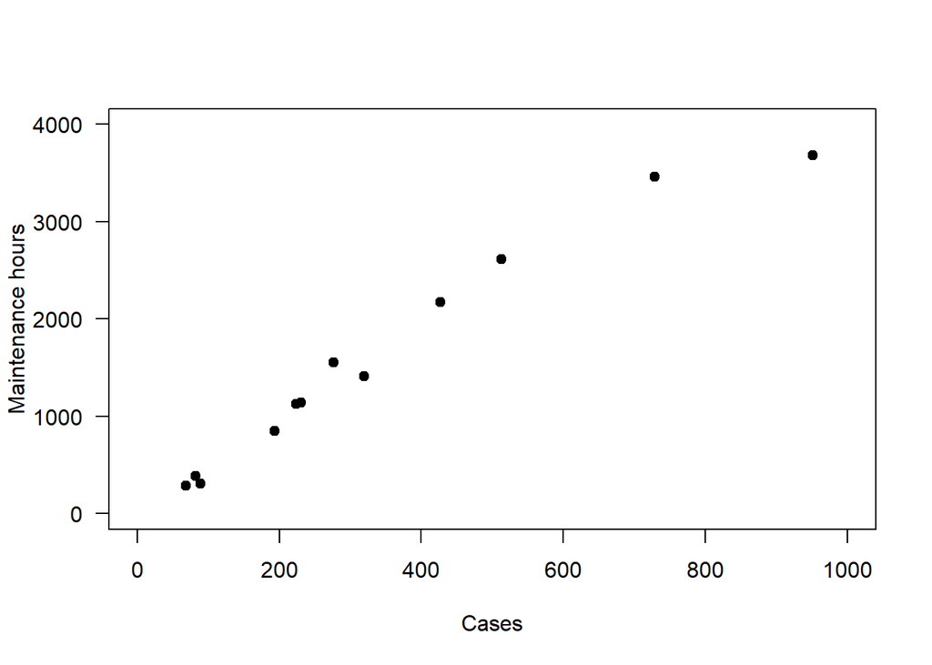

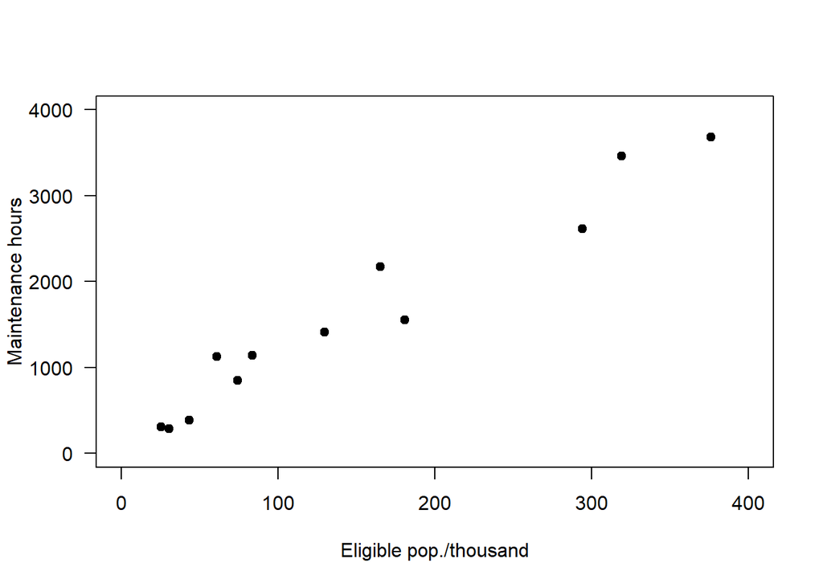

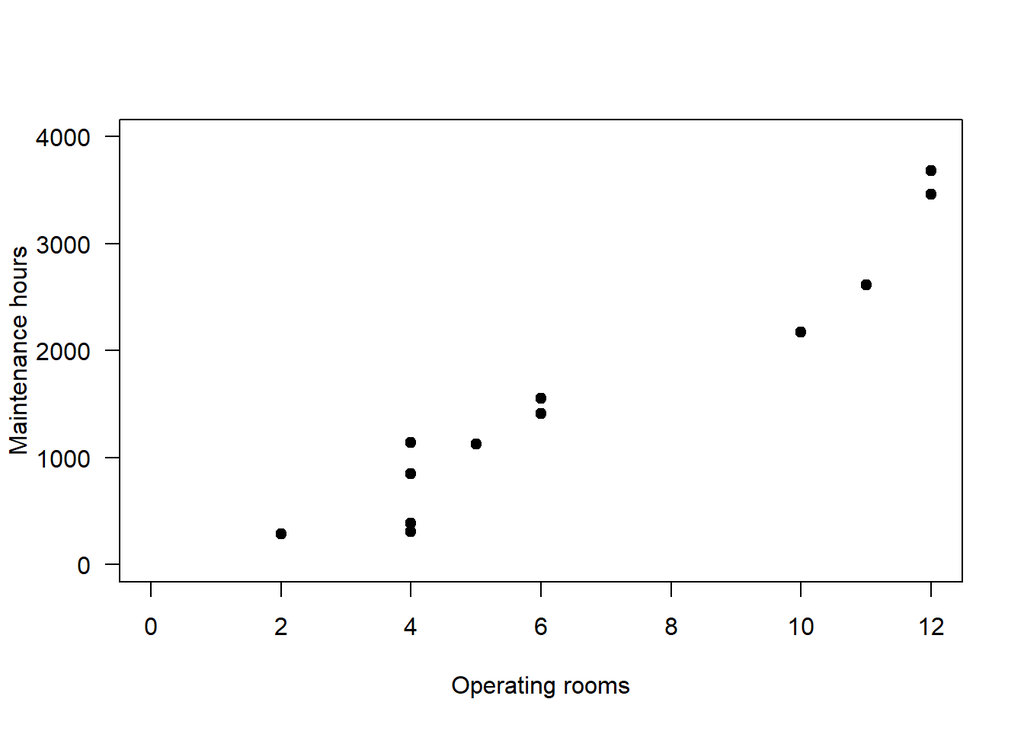

```
##               Cases  Eligible   OpRooms MainHours
## Cases     1.0000000 0.9602926 0.9264237 0.9802365
## Eligible  0.9602926 1.0000000 0.9399181 0.9749010
## OpRooms   0.9264237 0.9399181 1.0000000 0.9630730
## MainHours 0.9802365 0.9749010 0.9630730 1.0000000
```

```
##               Estimate Std. Error t value Pr(>|t|)
## (Intercept) -114.58953  130.33919 -0.8792  0.40494
## Eligible       2.27138    1.68197  1.3504  0.21384
## OpRooms       99.72542   42.21579  2.3623  0.04580 *
## Cases          2.03154    0.67779  2.9973  0.01714 *
## ---
## Signif. codes:  0 '***' 0.001 '**' 0.01 '*' 0.05 '.' 0.1 ' ' 1
```

## case study 2

```
## Analysis of Variance Table
##
## Response: DMFT
##             Df  Sum Sq Mean Sq F value    Pr(>F)
## Sugar        1  49.836  49.836 26.3196 1.768e-06 ***
## Indus        1   1.812   1.812  0.9572   0.33065
## Sugar:Indus  1   6.674   6.674  3.5248   0.06385 .
## Residuals   86 162.840   1.893
## ---
## Signif. codes:  0 '***' 0.001 '**' 0.01 '*' 0.05 '.' 0.1 ' ' 1
```

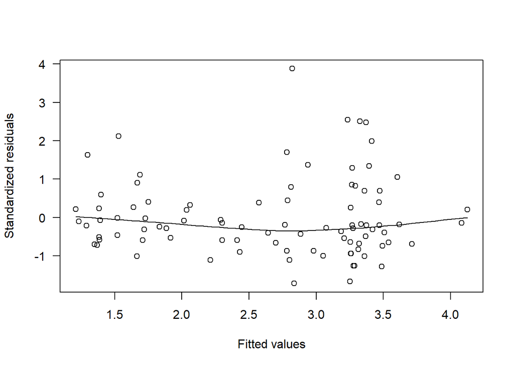

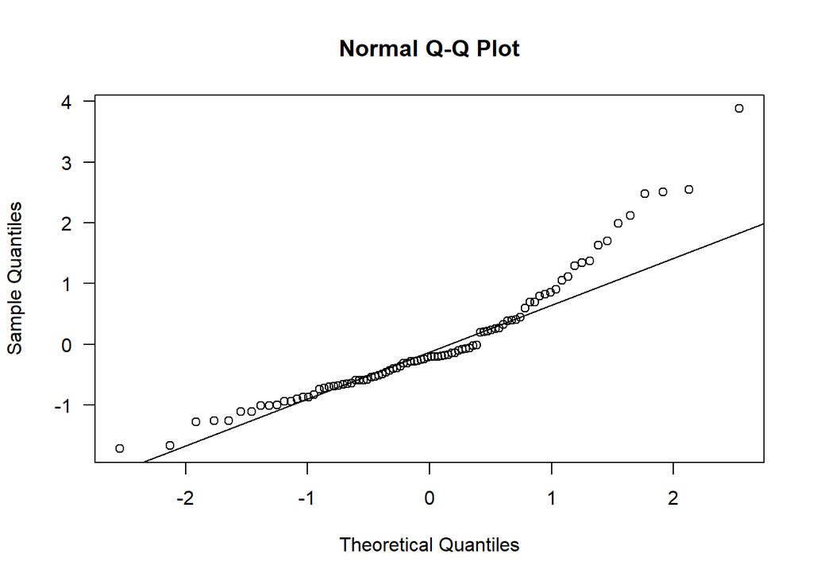

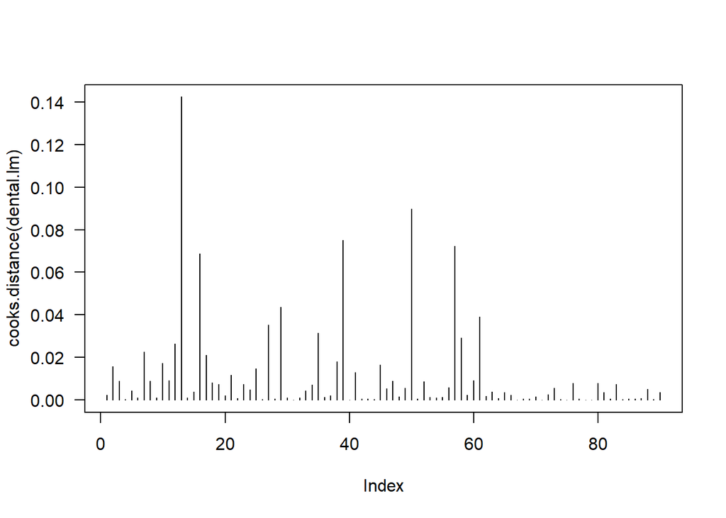

```
##   dfb.1_ dfb.Sugr dfb.InNI dfb.S:IN    dffit    cov.r   cook.d      hat
##        0        0        0        0        2       11        0        2
```

DMFT is a strictly positive response variable that varies over an order of magnitude between countries, so a log-transformation may well be helpful:

```
## Analysis of Variance Table
##
## Response: log(DMFT)
##             Df  Sum Sq Mean Sq F value    Pr(>F)
## Sugar        1 10.9773 10.9773 36.8605 3.332e-08 ***
## Indus        1  0.6183  0.6183  2.0761   0.15326
## Sugar:Indus  1  1.3772  1.3772  4.6245   0.03432 *
## Residuals   86 25.6113  0.2978
## ---
## Signif. codes:  0 '***' 0.001 '**' 0.01 '*' 0.05 '.' 0.1 ' ' 1
```

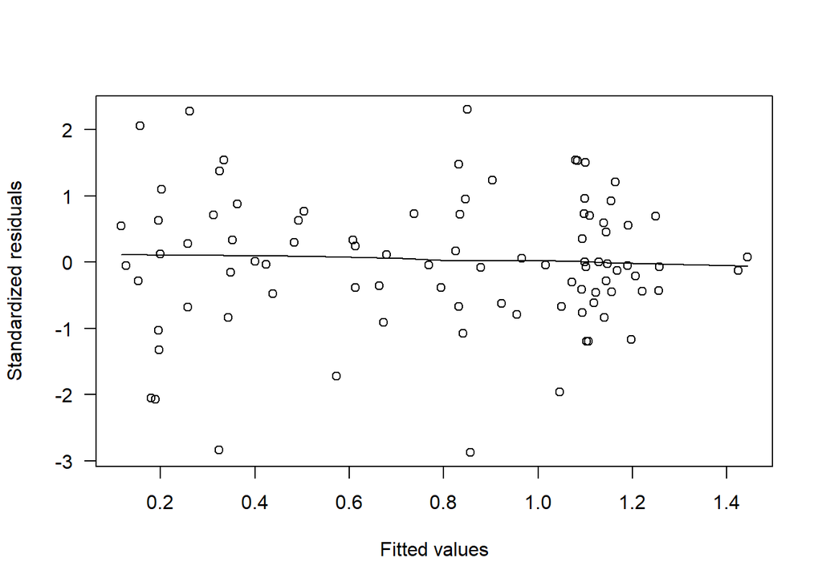

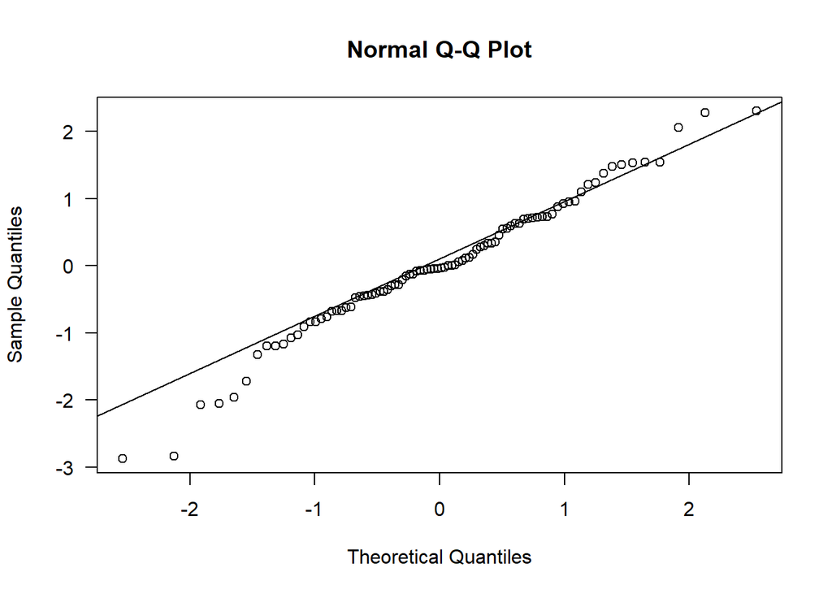

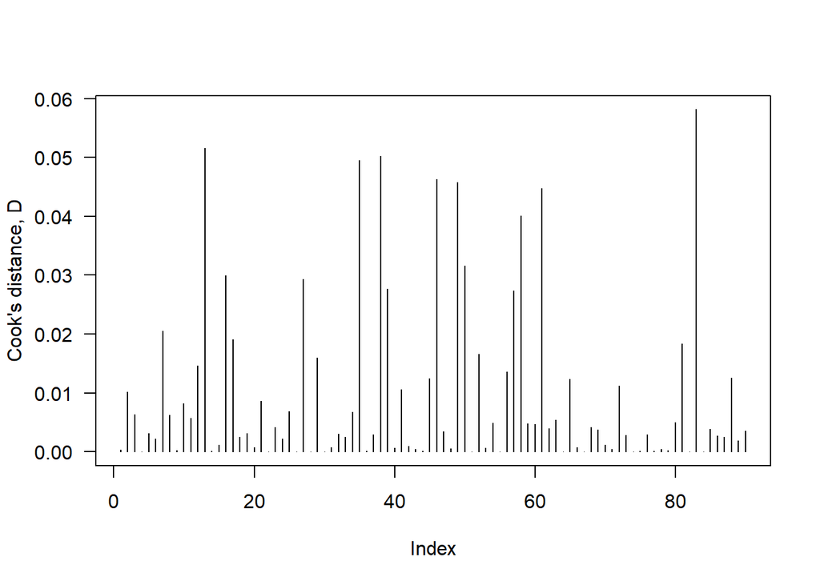

```
##   dfb.1_ dfb.Sugr dfb.InNI dfb.S:IN    dffit    cov.r   cook.d      hat
##        0        0        0        0        0       11        0        2
```

```
##     AIC (DMFT) AIC (log-DMFT)
##       61.36621     -105.10967
```

```
##     BIC (DMFT) BIC (log-DMFT)
##       413.3662       246.8903
```

In both cases, the model using log(DMFT) as the response variable is preferred.

## case study 3

To understand the how the chemical composition of cheese is related to its taste:

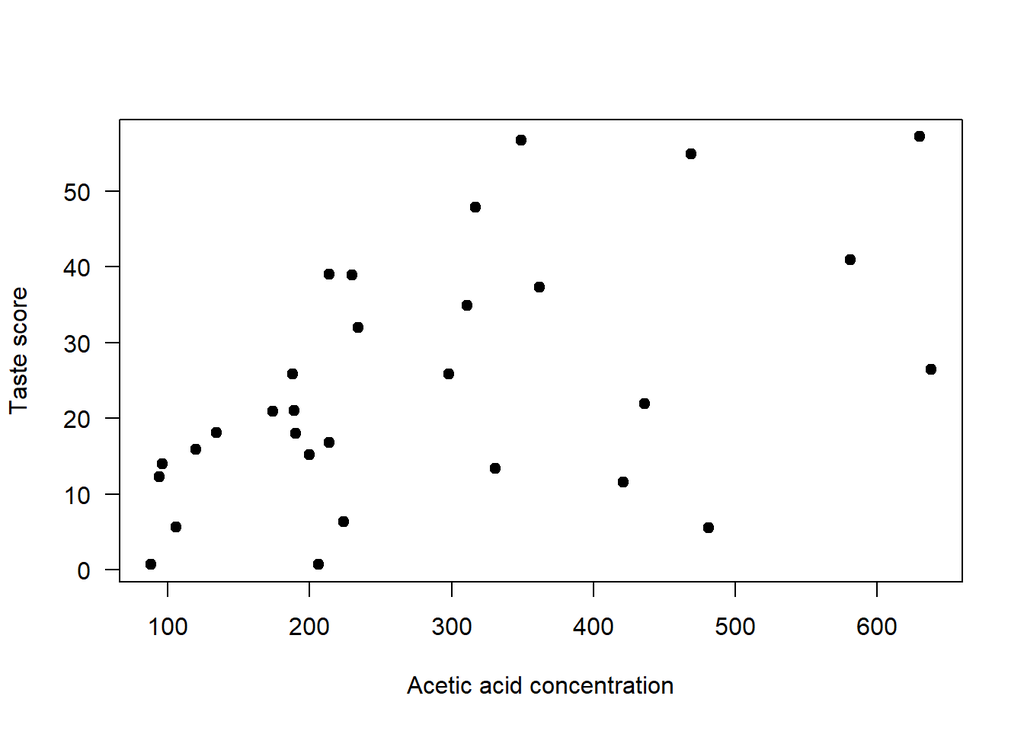

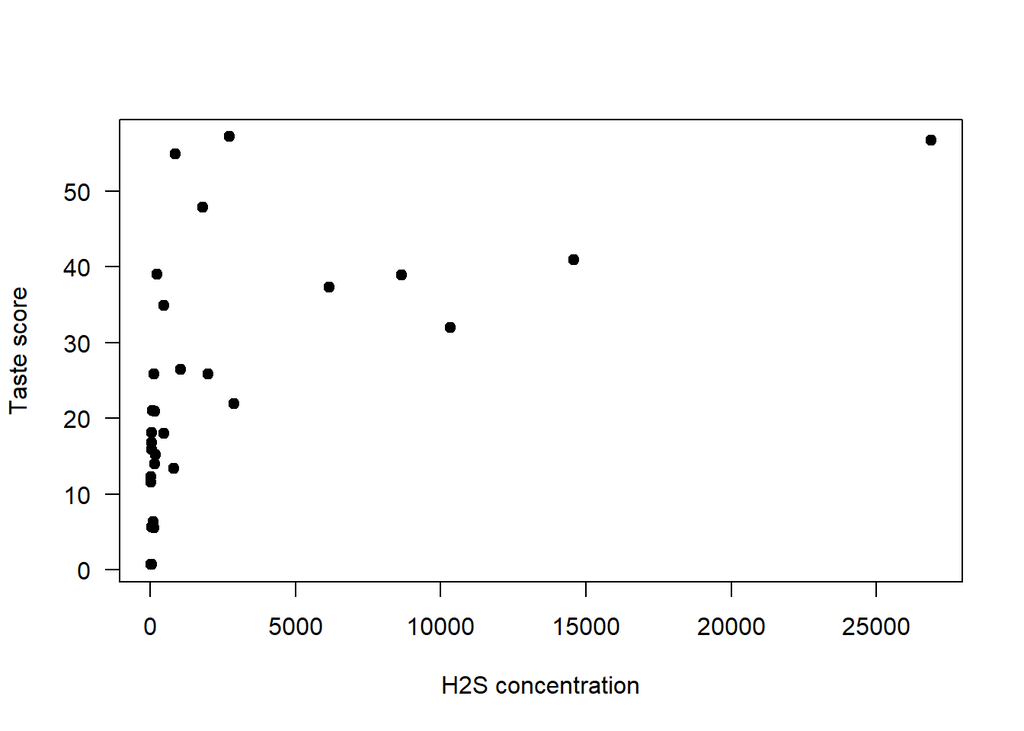

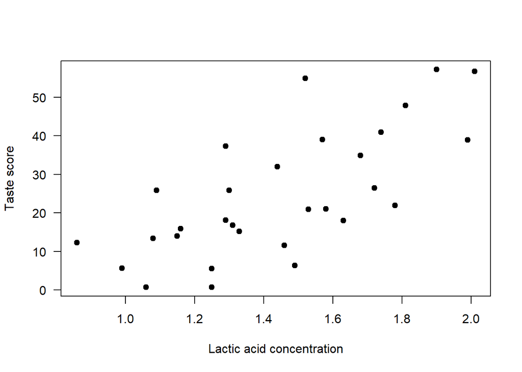

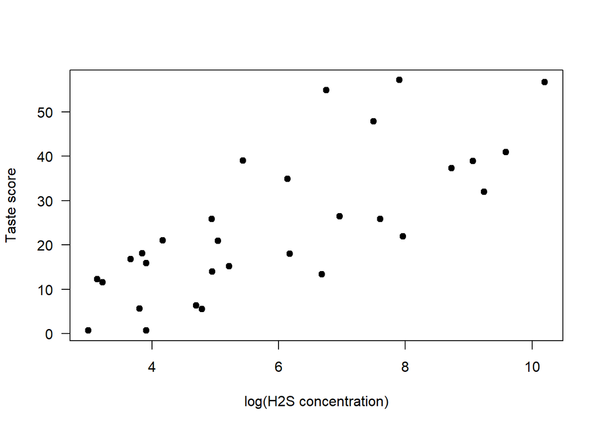

```
## Single term deletions
##
## Model:
## Taste ~ Acetic * log(H2S) * Lactic
##                        Df Sum of Sq    RSS    AIC F value Pr(>F)
## <none>                              2452.3 148.11
## Acetic:log(H2S):Lactic  1    36.467 2488.8 146.55  0.3272 0.5731
```

```
## Single term deletions
##
## Model:
## Taste ~ Acetic + log(H2S):Lactic + Acetic:log(H2S):Lactic
##                        Df Sum of Sq    RSS    AIC F value Pr(>F)
## <none>                              2679.1 142.76
## Acetic:log(H2S):Lactic  1    24.269 2703.4 141.03  0.2355 0.6315
```

```
## Single term deletions
##
## Model:
## Taste ~ log(H2S) + Lactic + Acetic
##          Df Sum of Sq    RSS    AIC F value   Pr(>F)
## <none>                2660.9 142.56
## log(H2S)  1   1012.39 3673.3 150.23  9.8922 0.004126 **
## Lactic    1    527.53 3188.4 145.98  5.1546 0.031706 *
## Acetic    1      8.05 2668.9 140.65  0.0787 0.781291
## ---
## Signif. codes:  0 '***' 0.001 '**' 0.01 '*' 0.05 '.' 0.1 ' ' 1
```

```
##            Taste    Acetic    logH2S    Lactic
## Taste  1.0000000 0.5131983 0.7557637 0.7042362
## Acetic 0.5131983 1.0000000 0.5548159 0.5410837
## logH2S 0.7557637 0.5548159 1.0000000 0.6448351
## Lactic 0.7042362 0.5410837 0.6448351 1.0000000
```

```
##               Estimate Std. Error   t value    Pr(>|t|)
## (Intercept) -27.591089   8.981801 -3.071888 0.004813785
## log(H2S)      3.946425   1.135722  3.474817 0.001742652
## Lactic       19.885953   7.959175  2.498494 0.018858866
```

- three-way interaction is not needed.
- two-way interaction is not needed
- Acetic is not needed

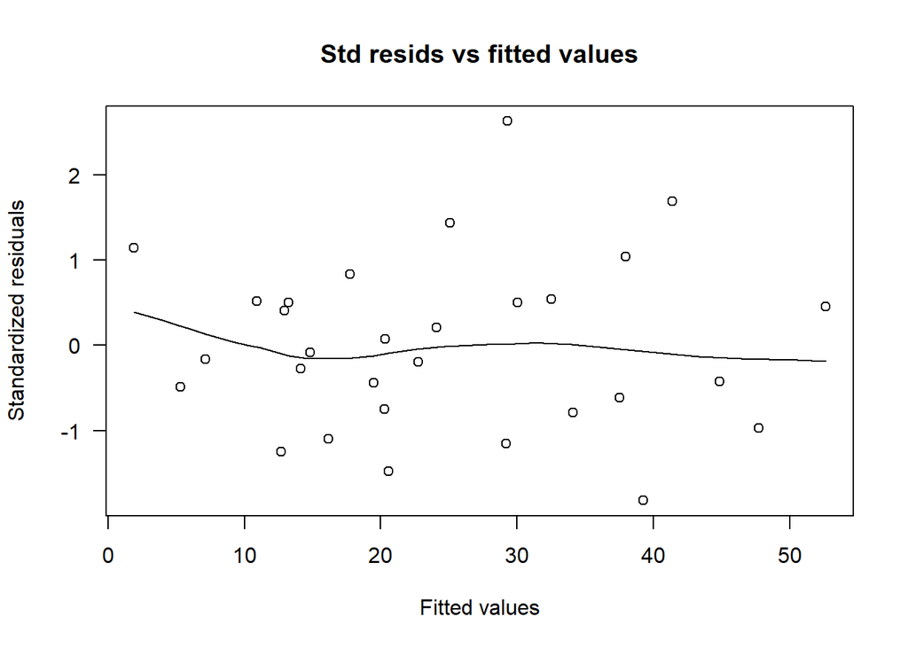

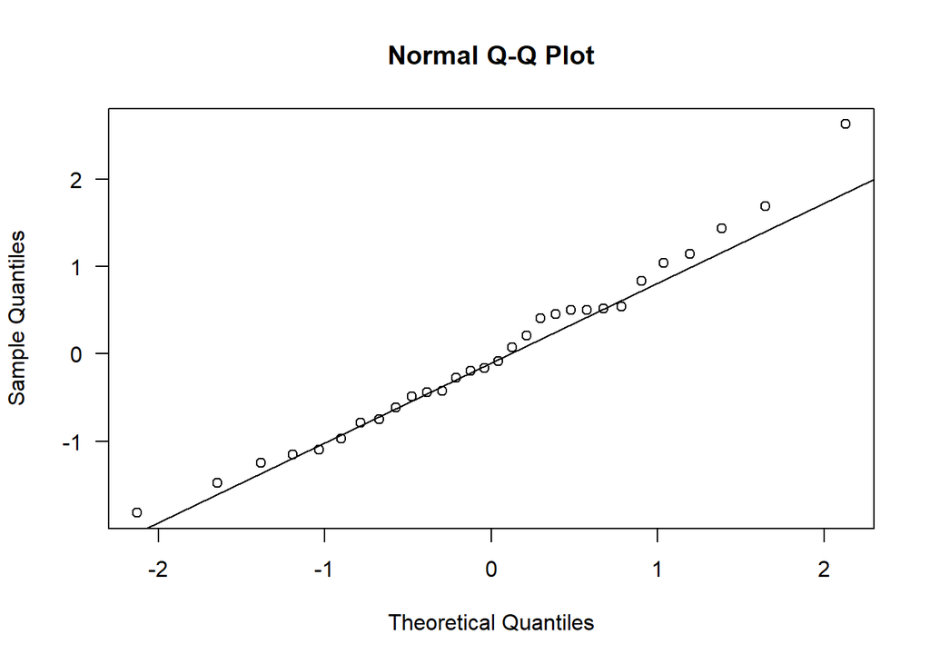

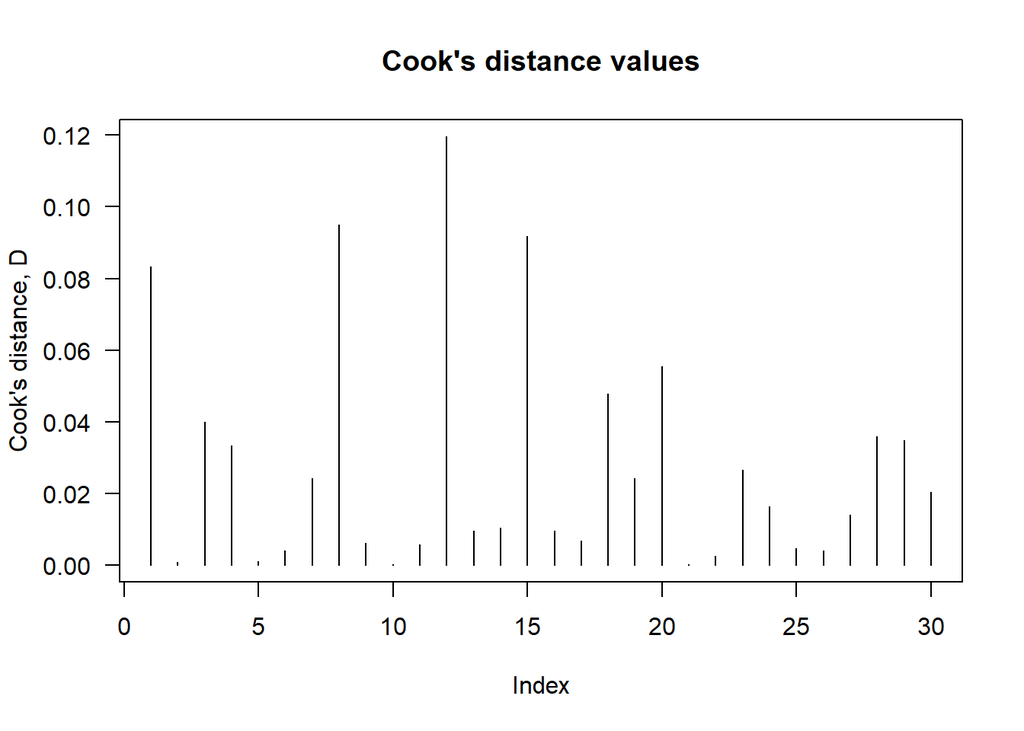

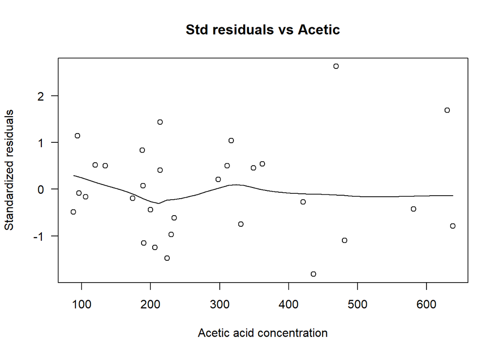

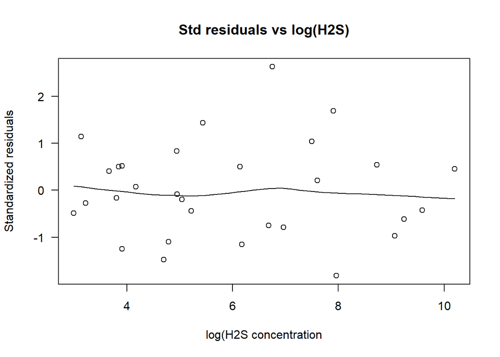

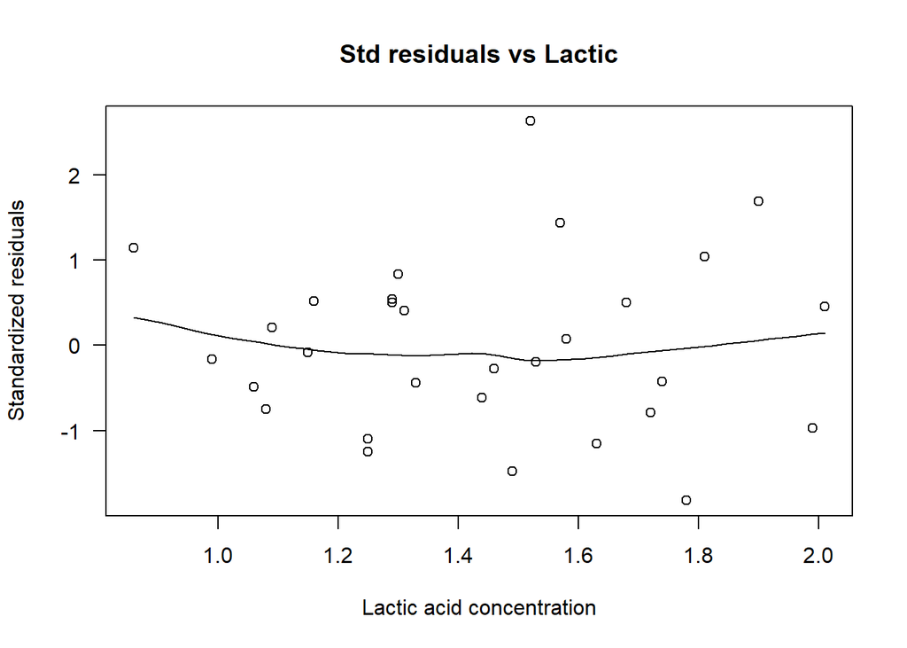

```
##   dfb.1_ dfb.l(H2 dfb.Lctc    dffit    cov.r   cook.d      hat
##        0        0        0        0        4        0        0
```